# From Probability to Likelihood

## Frequency Distribution of Heads

### 6 Flips

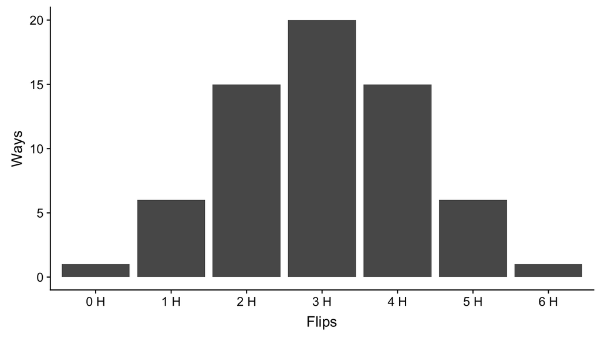

## Probability Distribution of Heads

### 6 Flips

```r
flips$Ways
```

```
## [1]  1  6 15 20 15  6  1
```

```r
flips$Ways / sum(flips$Ways)
```

```
## [1] 0.015625 0.093750 0.234375 0.312500 0.234375 0.093750 0.015625
```

## Probability Distribution of Heads

### 6 Flips

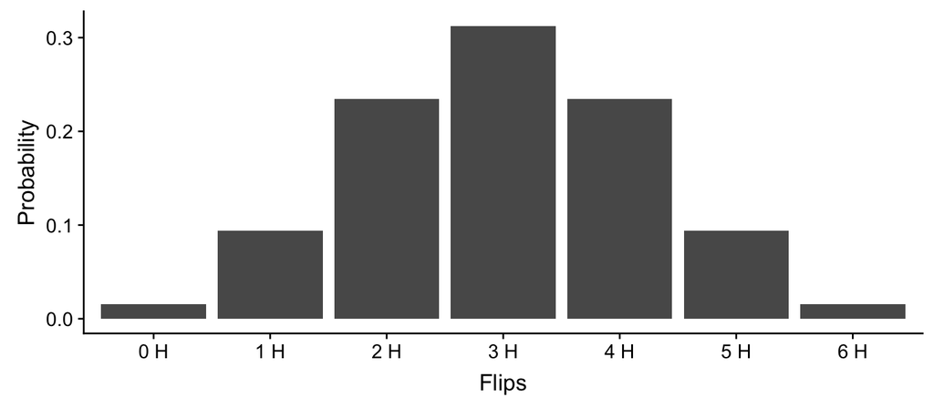

How can we go from a set of probabilities to likelihoods?

## Model Likelihood (\(\mathcal{L}\))

For a set of observations (\(Y_i\)) and hypothesized parameters (\(\Theta\)) the model likelihood is the product of the observations’ individual likelihoods:

\[\mathcal{L}\left(\left\{ Y_{i}\right\} _{i=1}^{n};\Theta\right) = \prod_{i=1}^{n}\phi\left(Y_{i}; \Theta\right)\]

Evaluate the likelihood function for different values of \(\Theta\) to estimate \(\mathcal{L}\) for different sets of \(\Theta\).

**Maximize \(\mathcal{L}\) and you will have the maximum likelihood set of parameter estimates.**

## Model Likelihood (\(\mathcal{L}\))

The product of a large number of probabilities can result in some very small numbers.

- Computers don’t handle really small numbers very well
  - There is a lower limit to the smallest number a computer can keep track of.
  - This is \(2.2250739\times 10^{-308}\) in R.

Think about computing the model likelihood with thousands or millions of observations.

```r
.09^150
```

```
## [1] 1.368915e-157
```

## Model Likelihood (\(\mathcal{L}\))

Usually easier to maximize the (natural) log of the likelihoods.

- The log-likelihood is easier to deal with mathematically.

\[\mathcal{L}\left(\left\{ Y_{i}\right\} _{i=1}^{n};\Theta\right) = \prod_{i=1}^{n}\phi\left(Y_{i}; \Theta\right)\]

Log both sides of the equation:

\[\log\left(\mathcal{L}\left(\left\{ Y_{i}\right\} _{i=1}^{n};\Theta\right)\right) = \log\left(\prod_{i=1}^{n}\phi\left(Y_{i};\Theta\right)\right)\]

## Model Likelihood (\(\mathcal{L}\))

Taking advantage of the algebraic rules associated with logs (the log of the products equals the sum of the logs):

\[\log\left(\mathcal{L}\left(\left\{ Y_{i}\right\} _{i=1}^{n};\Theta\right)\right) = \sum_{i=1}^{n} \log\left(\phi\left(Y_{i};\Theta\right)\right)\]

So we just need to sum the log-likelihoods of the observations to get the model likelihood.

*Note*: `log()` is *natural* log.

## Likelihood of coin flips

You have 3 heads from 6 coin flips (i.e., 1 observation)

- What is the maximum likelihood estimate of the probability of heads \((\theta)\)?
- \(\theta\) can be any value from 0 to 1 (but we won’t include 0 or 1).

## log-Likelihood for one value of \(\theta\)

Hypothesize that \(\theta = 0.2\), observe 3 heads from 6 flips. What is the likelihood?

```r
theta <- 0.2
pr <- dbinom(3, 6, prob = theta)
pr
```

```
## [1] 0.08192
```

```r
log(pr)
```

```
## [1] -2.502012
```

## Likelihood across the range of 0 to 1

Generate a range of possible values for \(\theta\):

```r
theta <- seq(0.001, 0.999, length = 200)
```

Calculate the probability for 3 heads for each value of \(\theta\):

```r
pr <- dbinom(3, 6, prob = theta)
```

Convert to log-likelihoods:

```r
log_lik <- log(pr)
log_liks <- tibble(theta, log_lik)
```

```r
log_liks
```

```
## # A tibble: 200 x 2
##      theta log_lik
##      <dbl>   <dbl>
##  1 0.001    -17.7
##  2 0.00602  -12.4
##  3 0.0110   -10.6
##  4 0.0160    -9.45
##  5 0.0211    -8.65
##  6 0.0261    -8.02
##  7 0.0311    -7.51
##  8 0.0361    -7.08
##  9 0.0411    -6.70
## 10 0.0461    -6.37
## # … with 190 more rows
```

## Likelihood across the range of 0 to 1

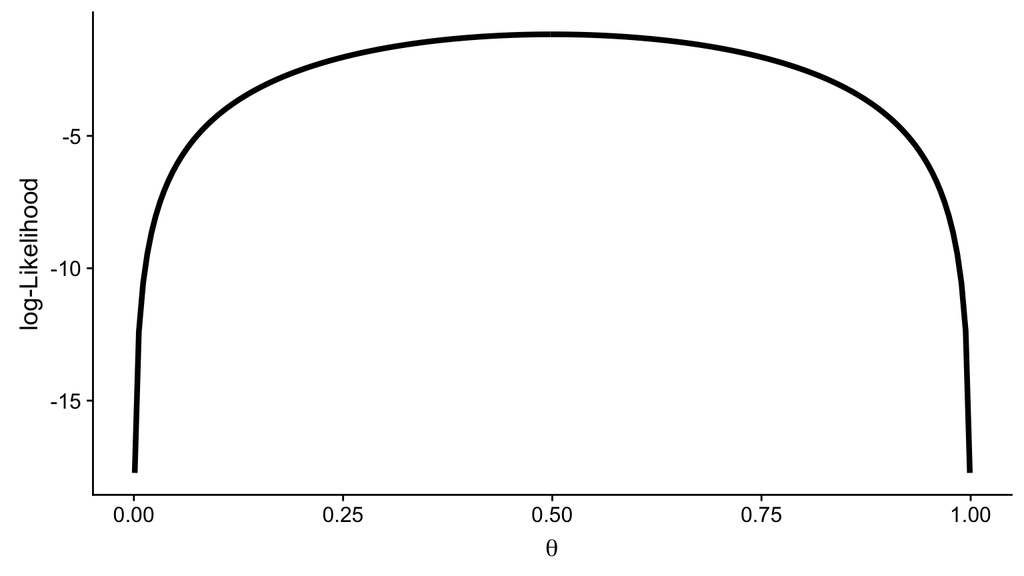

## Maximum likelihood

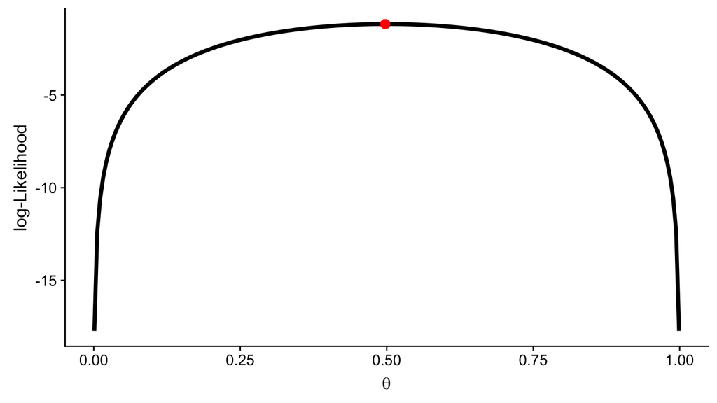

## Maximum likelihood

```r
max(log_lik)
```

```
## [1] -1.163226
```

```r
theta[which.max(log_lik)]
```

```
## [1] 0.4974925
```

## Likelihood of coin flips

You have 20 heads from 60 coin flips.

- What is the maximum likelihood estimate of the probability of heads (\(\theta\))?
- \(\theta\) can be any value from 0 to 1.

## Likelihood across the range of 0 to 1

```r
theta <- seq(0.001, 0.999, length = 200)
pr <- dbinom(20, 60, prob = theta)
log_lik <- log(pr)
log_liks <- tibble(theta, log_lik)
```

## Likelihood across the range of 0 to 1

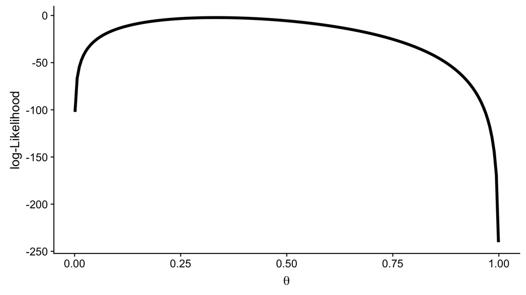

## Maximum likelihood

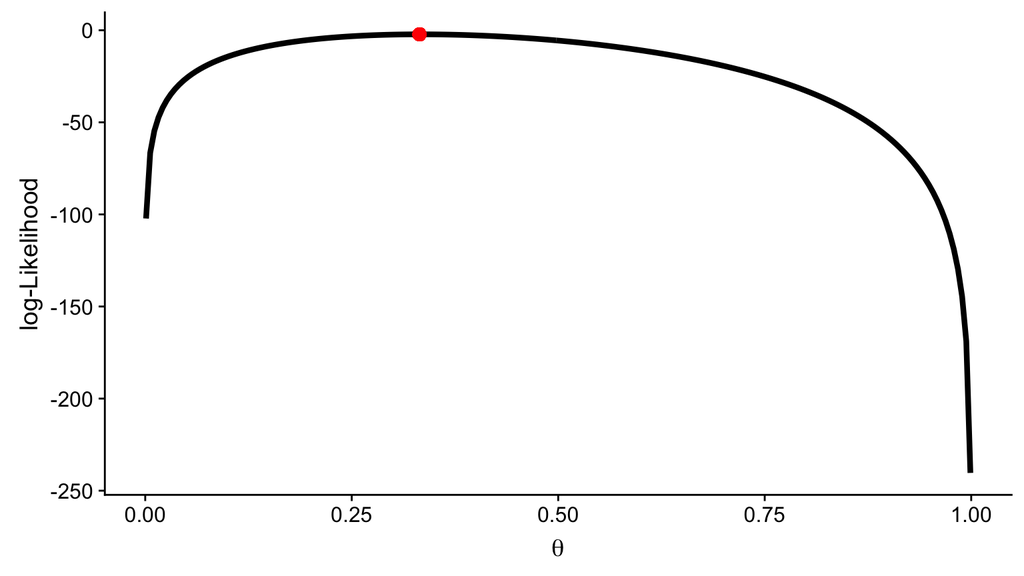

## Maximum likelihood

```r
max(log_lik)
```

```
## [1] -2.219175
```

```r
theta[which.max(log_lik)]
```

```
## [1] 0.331995
```

## Likelihood of coin flips

You have 20000 heads from 60000 coin flips.

- What is the maximum likelihood estimate of the probability of heads (\(\theta\))?
- \(\theta\) can be any value from 0 to 1.

## Likelihood across the range of 0 to 1

```r
theta <- seq(0.001, 0.999, length = 200)
pr <- dbinom(20000, 60000, prob = theta)
log_lik <- log(pr)
log_liks <- tibble(theta, log_lik)
```

## Maximum likelihood

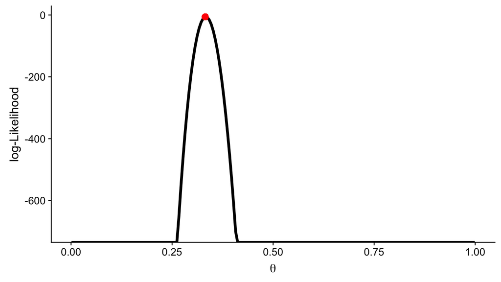

## Quiz 04-2

Complete quiz 04-2.

Move on to Lecture 04-3.